# Доклад

Перспектива и инновация

Иванов Сергей Владимирович, НПИбд-01-23

Российский университет дружбы народов, Москва, Россия

26 марта 2026

## Докладчик

- Иванов Сергей Владимирович
- Студент НПИбд-01-23
- Российский университет дружбы народов
- [1132236127@pfur.ru]

## Введение

Сложность задач в современном мире растёт экспоненциально. Математическое моделирование позволяет формализовать проблему и найти оптимальное решение.

В докладе рассмотрим два ключевых понятия:

- **Перспектива** — способ представления множества решений
- **Инновация** — смена перспективы для преодоления локальных оптимумов

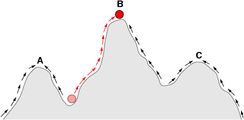

Ландшафт приспособленности

## Что такое перспектива?

**Перспектива** — это представление множества всех возможных решений данной проблемы, то есть способ кодирования потенциальных решений.

Перспектива включает в себя:

1. **Множество объектов (решений):** все варианты действий, которые мы можем предпринять.
2. **Способ отображения:** как эти решения соотносятся друг с другом.

Выбор перспективы определяет **рельеф ландшафта** задачи — будет ли он пологим, холмистым или состоящим из острых пиков.

## Зависимость перспективы от проблемы

Перспектива жёстко привязана к проблеме. Одна и та же перспектива может быть:

- **Идеальной** для задачи планирования бюджета
- **Бесполезной** для дизайна аэродинамического крыла

*Пример:* задача поиска кратчайшего пути между городами:

- Геометрический подход — точки на плоскости
- Топологический подход — узлы графа с весами

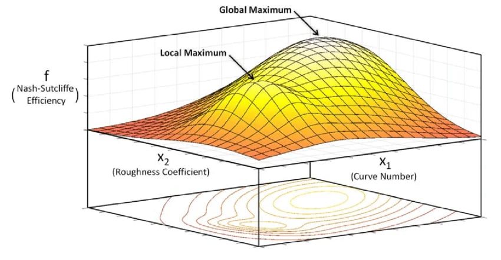

Локальный и глобальный оптимум

## Локальные оптимумы

В процессе оптимизации мы стремимся найти **глобальный оптимум** — наивысшую точку ландшафта.

**Локальный оптимум** — решение, лучшее среди своих «соседей», но не наилучшее в принципе.

Алгоритмы (и люди) часто застревают в локальных оптимумах:

- С вершины небольшого холма любой шаг ухудшает результат
- Кажется, что решение найдено
- Но за долиной может быть гораздо более высокая гора

## Наилучшая перспектива

**Наилучшая перспектива** — та, локальный оптимум которой максимально близок к глобальному.

Если текущая модель даёт неудовлетворительные локальные максимумы — это сигнал: нужно не улучшать решение, а менять саму перспективу

## Теорема Саванта

**Формулировка:** для любой проблемы существует перспектива, создающая ландшафт с одним-единственным экстремумом.

**Следствие:** в таком ландшафте любая стратегия восхождения (градиентный спуск, перебор соседей) неизбежно приведёт к вершине — тупиков нет.

**Доказательство:** если мы знаем глобальный оптимум, можно выстроить все решения в ряд по убыванию эффективности — задача становится тривиальной.

## Почему это сложно на практике?

Теорема Саванта **гарантирует существование** идеальной перспективы, но не даёт алгоритма её поиска.

Зачастую поиск идеальной перспективы сложнее, чем решение задачи в плохой перспективе.

Однако само знание того, что такая точка зрения существует, стимулирует инновационную деятельность.

## Инновация как смена перспективы

**Инновация** — обнаружение новой перспективы, устраняющей локальные оптимумы.

- **Эволюция** — подъём по склону текущего холма
- **Инновация** — «прыжок» на другой склон или перестройка ландшафта

*Пример:* переход от классической механики к квантовой — смена перспективы, открывшая решения тупиковых задач XIX века.

## Разнообразие перспектив

Группа людей с разными перспективами справляется с задачей лучше, чем один эксперт с одной очень хорошей перспективой.

Причина: локальный оптимум для одного человека **не является таковым для другого**. Там, где один застрял на холме, другой видит склон, ведущий выше.

## Области применения

1. **Бизнес и менеджмент** — мозговой штурм как поиск новых перспектив; выявление скрытых потребностей рынка.
2. **Экономическое прогнозирование** — разные модели открывают разные ландшафты рисков.
3. **ИИ и машинное обучение** — обучение нейросетей как поиск минимума функции потерь; переход к трансформерам — реализация теоремы Саванта.
4. **Государственное управление** — буксующая реформа = локальный оптимум; нужен инновационный взгляд на структуру общества.

## Вывод

Математическое моделирование — это не только расчёты, но и философская работа по выбору точки обзора.

- **Перспектива** определяет ландшафт задачи и качество достижимых решений
- **Теорема Саванта** гарантирует: для любой проблемы существует идеальная перспектива
- **Инновация** — это и есть поиск этой идеальной точки зрения

Успех в принятии решений зависит от способности постоянно пересматривать модели и комбинировать различные перспективы.

## Список литературы

1. https://ru.wikipedia.org/wiki/Математическое_моделирование

2. https://ru.wikipedia.org/wiki/Оптимизация_(математика)

3. https://ru.wikipedia.org/wiki/Теория_принятия_решений

4. https://www.ibm.com/think/topics/optimization-model

5. https://habr.com/ru/articles/808757/

6. https://abiturient.tpu.ru/news/my-sozdaem-mir-kak-matematiceskoe-modelirovanie-pomogaet-proizvodstvam-medicine-i-finansovym-rynkam